# Exploratory Analysis Zillow

### Where does Zestimate over or underpredict?

A high absolute logerror tells us predictions are not that good. But this could either be driven by underpredicting or overpredicting sale price.

```r
tmptrans <- tmptrans %>% mutate(overunder = ifelse(logerror<0,"under","over"))
```

Again, we see that there is no clear correlation. However, for some range in the data Zestimate tends to overpredict more than to underpredict (see where the red line is above the blue one).

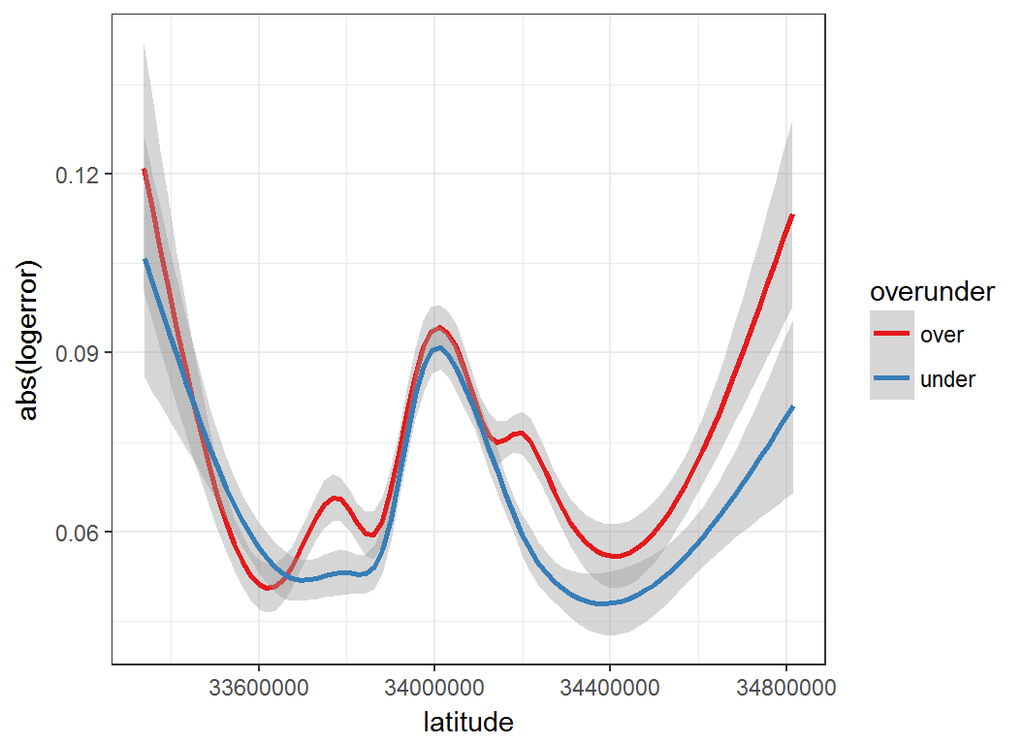

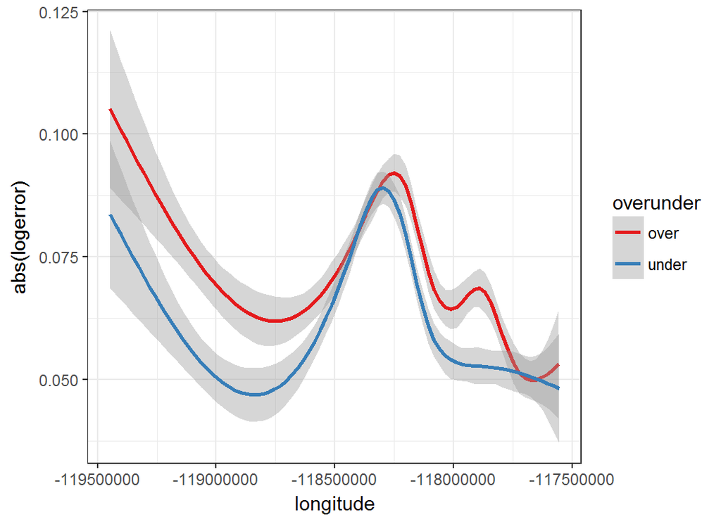

Both for latitude and longitude there is a range where Zestimate both under- and overpredicts.

Where is that?

```r
leaflet() %>%
  addTiles() %>%
  fitBounds(-118.5,33.8,-118.25,34.15) %>%
  addRectangles(-118.5,33.8,-118.25,34.15) %>%
  addMiniMap()
```

[interactive chart not shown]

For properties with small calculated total area, Zestimate seems to overpredict.

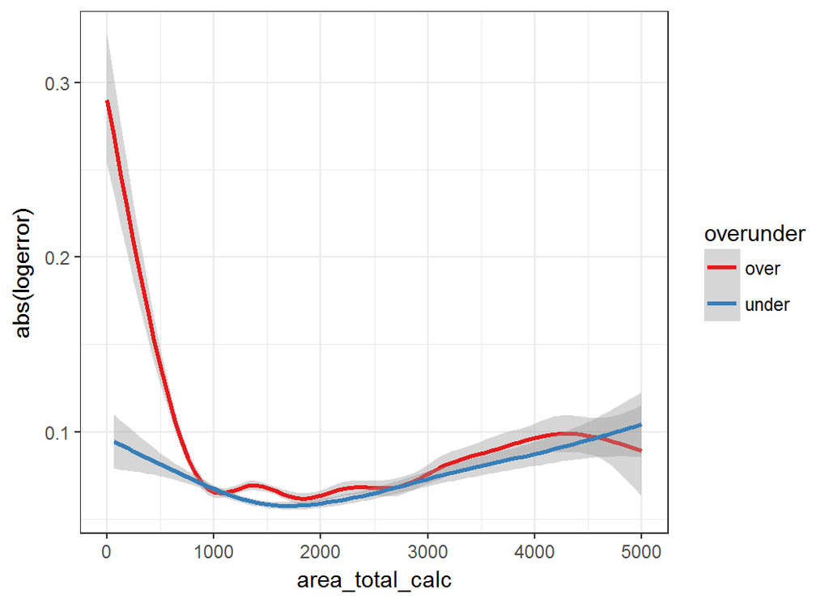

Whereas for actual finished area there is no such effect.

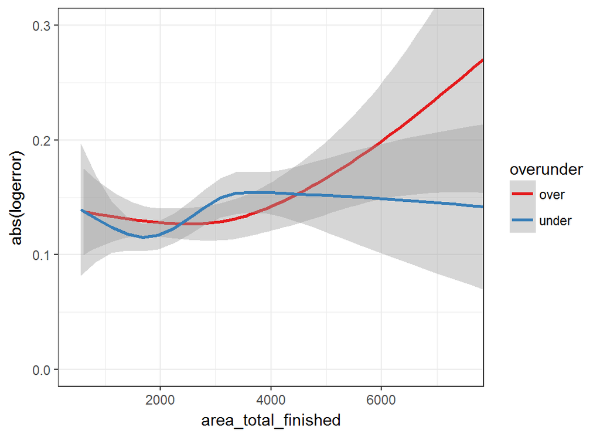

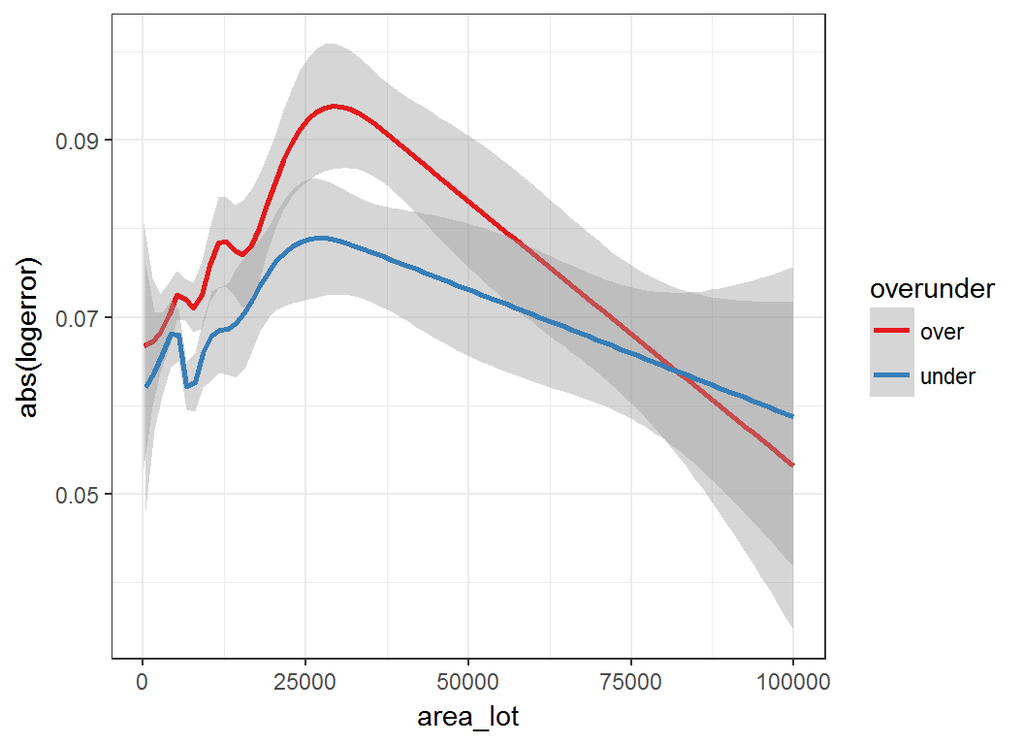

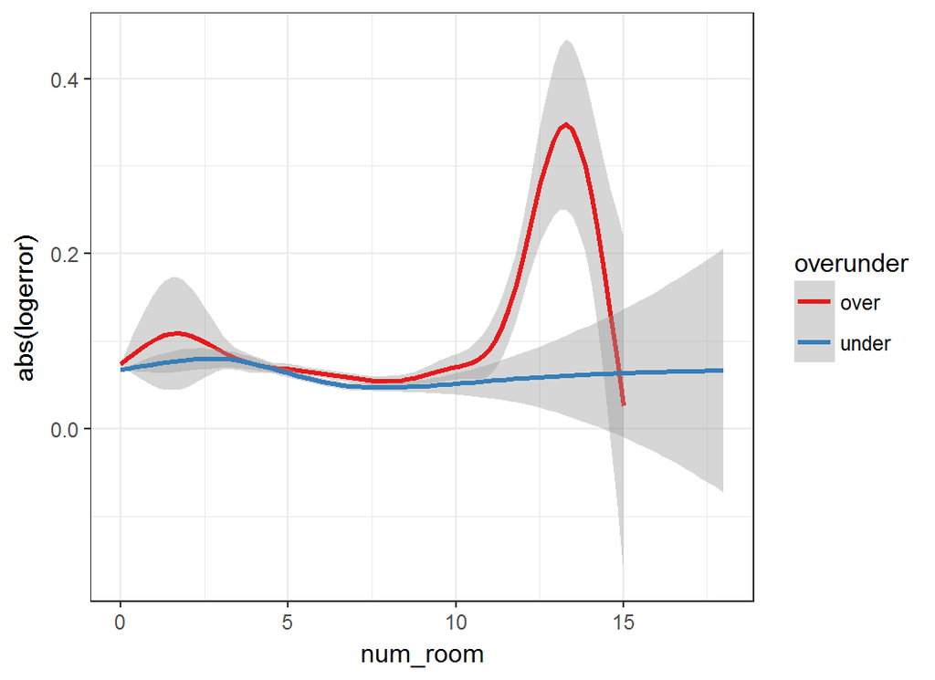

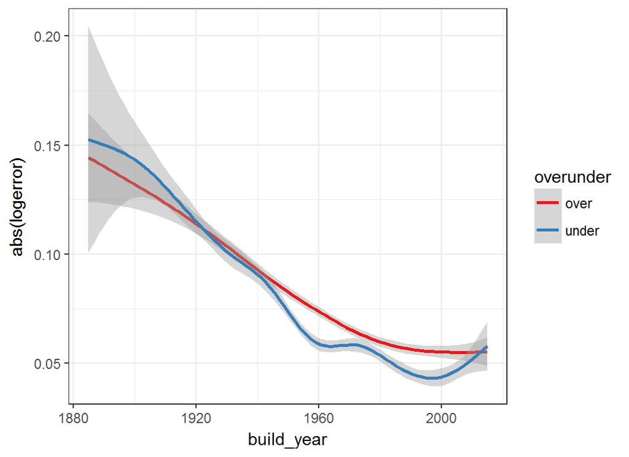

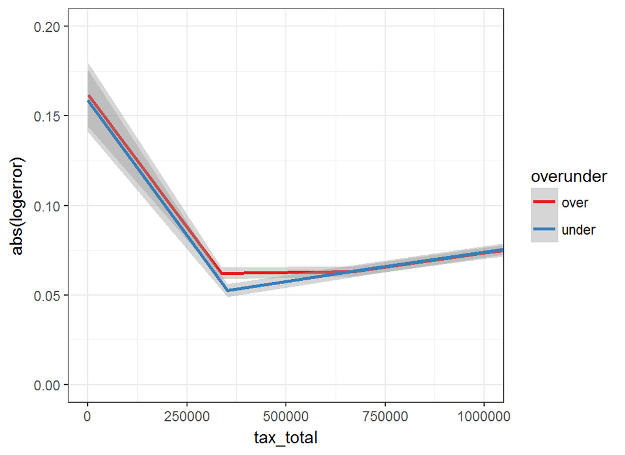

### Where are all those properties?

Show 2,000 of the properties on the map.

```r
lat <- range(properties$latitude/1e06,na.rm=T)
lon <- range(properties$longitude/1e06,na.rm=T)

tmp <- properties %>%
  sample_n(2000) %>%
  select(id_parcel,longitude,latitude) %>%
  mutate(lon=longitude/1e6,lat=latitude/1e6) %>%
  select(id_parcel,lat,lon) %>%
  left_join(transactions,by="id_parcel")

leaflet(tmp) %>%
  addTiles() %>%
  fitBounds(lon[1],lat[1],lon[2],lat[2]) %>%
  addCircleMarkers(stroke=FALSE) %>%
  addMiniMap()
```

[interactive chart not shown]

### Map absolute logerror

Show the absolute logerror on map. Red = higher.

```r
tmp <- transactions %>%
  sample_n(2000) %>%
  left_join(properties,by="id_parcel") %>%
  select(id_parcel,longitude,latitude, abs_logerror) %>%
  mutate(lon=longitude/1e6,lat=latitude/1e6) %>%
  select(id_parcel,lat,lon, abs_logerror)

qpal <- colorQuantile("YlOrRd", tmp$abs_logerror, n = 7)

leaflet(tmp) %>%
  addTiles() %>%
  fitBounds(lon[1],lat[1],lon[2],lat[2]) %>%
  addCircleMarkers(stroke=FALSE, color=~qpal(abs_logerror),fillOpacity = 1) %>%
  addLegend("bottomright", pal = qpal, values = ~abs_logerror,title = "Absolute logerror",opacity = 1) %>%
    addMiniMap()
```

[interactive chart not shown]

### What do these features mean?

I was really unsure about the meaning of the variables:

- ‘rawcensustractandblock’

A wikipedia search revealed:

Census tracts represent the smallest territorial unit for which population data are available in many countries.[3] In the United States, census tracts are subdivided into block groups and census blocks. In the U.S., census tracts are “designed to be relatively homogeneous units with respect to population characteristics, economic status, and living conditions” and “average about 4,000 inhabitants”.

```r
str(properties$rawcensustractandblock[1])
```

```
##  num 60378002
```

Looks like a number. However a closer look reveals its actually a number composed of two parts, separated by a dot.

```r
as.character(properties$rawcensustractandblock[1])
```

```
## [1] "60378002.041"
```

Ok, so far so good. So from what I read this number consisits of: FIPS Code (6037) - Tract Number (8002.04) - And block Number (1)

Let’s specifically add the tract number and block number information

```r
properties <- properties %>% mutate(census = as.character(rawcensustractandblock), tract_number = str_sub(census,5,11), tract_block = str_sub(census,12))
```

**An important note:**  
For round 1, the use of external data is not permitted. So save the pleasent anticipation for round 2 :-)

FIPS codes can be looked up [here](https://www.ffiec.gov/census/Default.aspx)

- 6037 Los Angeles
- 6059 Orange County
- 6111 Ventura County

Now, that you have the tract number you can get information such as tract income level, median family income, tract population, etc.

For our example “6037 8002.04” lets look up some information:

https://www.ffiec.gov/census/report.aspx?year=2016&county=037&tract=8002.04&state=06&report=demographic

For example: The median familiy income 2016 is $146,472.

I am going to add more information later. So stay tuned.

And:

If the kernel helped you and you **upvote**, you make me happy :-)